# Lecture 02: Probability for Econometrics (Appendix B)

What Does a Regression Predict?

Anchor question: Why can a wage equation be useful when it predicts individual wages badly?

The lecture moves from an unconditional wage distribution to conditional means, then to within- and between-group variation, and finally to the regression line.

## Learning outcomes

After this lecture, students should be able to:

1. **Interpret** unconditional and conditional expectations and explain why a regression prediction concerns an average relationship rather than an exact individual outcome.
2. **Compare** unconditional and conditional variation and relate between-group and within-group variation to what regression later calls explained and unexplained variation.
3. **Diagnose** why a strong statistical relationship can improve prediction without determining individual outcomes or establishing causality.

**NotePre-class / reference reading**

Review Appendix B on random variables, expected value and variance, with particular attention to **B.1.3–B.1.8**: joint/conditional distributions, covariance and correlation, conditional expectations, iterated expectations, and variance decomposition. The catalogue of specific distributions in B.3 is reference material for now.

**TipYou do not need to memorise this**

Do **not** memorise density formulas, integration derivations, proofs of iterated expectations or variance decomposition, Jacobians, truncated-distribution formulas, or the mathematical constructions of the $t$, $\chi^2$, and $F$ distributions. We will use those distributions later when an econometric problem requires them.

## 0. Retrieval and connection

Suppose last lecture gave us

$$\widehat{WAGE}_i=-12+2.5EDUC_i.$$

For a worker with 16 years of education,

$$\widehat{WAGE}=28.$$

**Retrieval question:** What does the number 28 mean?

- **A.** A worker with 16 years of education earns $28.
- **B.** Workers with 16 years of education earn about $28 **on average**.
- **C.** Education causes this worker to earn $28.

Last lecture we estimated relationships. Today we ask what fitted values mean in a world where economic outcomes are random.

## 1. The Hook

Consider four workers who all have 16 years of education:

| Worker | Education | Hourly wage |
| --- | --- | --- |
| A | 16 | $20 |
| B | 16 | $25 |
| C | 16 | $31 |
| D | 16 | $36 |

Yet our wage equation predicts

$$\widehat{WAGE}(16)=28.$$

**Predict before computing:** If none of these four workers earns exactly $28, is the prediction of $28 wrong?

Then decide which statements you expect to be true:

1. Average wages differ across education groups.
2. Individual wages still differ considerably within education groups.
3. Once education is known, almost all wage uncertainty disappears.

We will return to this decision after each lab step.

## 2. Minimal theory

### Random variable versus realization

$WAGE$ represents an uncertain economic outcome. An observed value such as $wage_i=24.50$ is one realization of that random variable.

### Unconditional versus conditional expectation

$$E(WAGE)$$

asks: *What wage should we expect for a randomly selected worker?*

By contrast,

$$E(WAGE\mid EDUC=16)$$

asks: *What wage should we expect for a randomly selected worker among workers with 16 years of education?*

**ImportantKey idea**

**Conditioning means using information.** Regression is largely about how the conditional distribution of an outcome changes when the information set changes.

### A conditional mean does not eliminate randomness

Conceptually, write

$$WAGE_i = E(WAGE\mid EDUC_i)+u_i.$$

The first component is systematic. The second reminds us that individual wages can still differ from the conditional mean.

### Total variation has two sources

$$\boxed{\text{Total variation}=\text{between-group variation}+\text{within-group variation}}$$

Formally,

$$\operatorname{Var}(Y)
=
\operatorname{Var}\!\left[E(Y\mid X)\right]
+
E\!\left[\operatorname{Var}(Y\mid X)\right].$$

For wages and education,

$$\operatorname{Var}(WAGE)
=
\underbrace{\operatorname{Var}[E(WAGE\mid EDUC)]}_{\text{differences between education groups}}
+
\underbrace{E[\operatorname{Var}(WAGE\mid EDUC)]}_{\text{differences within education groups}}.$$

No proof today. We will make the decomposition visible numerically.

### Explore the conditional mean

**Education:** 16 years

Conditional mean wage:

$28.00

Illustrative observed range in today’s teaching data: $20.00 to $36.00.

The mean moves systematically with education, but individual outcomes remain dispersed around it.

## 3. Econometric Lab

### Construct the teaching data

The live lab uses a transparent 40-worker CPS-style teaching dataset. There are ten workers at each education level $12,14,16,18$. The conditional means are $18,23,28,33$, while individual wages vary substantially around each group mean.

### Lab Step 1 — What does the unconditional wage distribution tell us?

**Question:** Before using education, what would we predict for a randomly selected worker?

**Prediction:** Decide what summary you would use before running the code.

```r
mean(workers$wage)
```

```
[1] 25.5
```

```r
range(workers$wage)
```

```
[1] 10 41
```

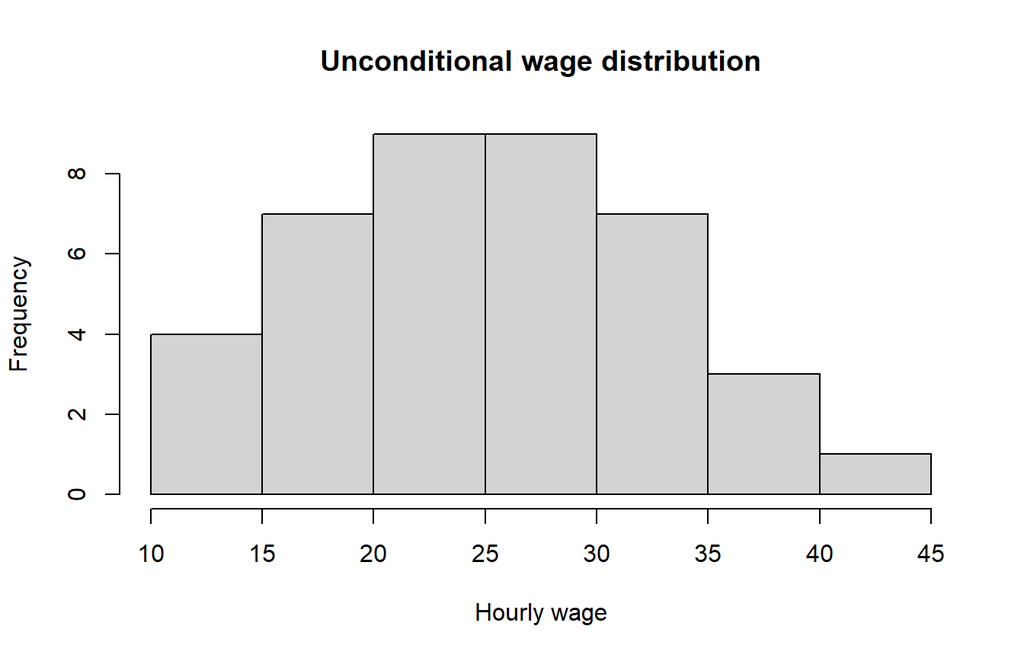

Unconditional distribution of hourly wages

```r
hist(
  workers$wage,
  breaks = 8,
  main = "Unconditional wage distribution",
  xlab = "Hourly wage"
)
```

**Verified result:**

$$\bar WAGE=25.5,
\qquad
WAGE\in[10,41].$$

**Interpretation:** With no information about a worker beyond membership in this population, $25.50 is the natural mean prediction. It is not an exact individual forecast.

**Decision:** The unconditional mean is useful, but knowing worker characteristics may improve prediction.

### Lab Step 2 — Does conditioning on education change what we expect?

**Question:** What happens to expected wage when we know education?

**Prediction:** Do you expect $E(WAGE\mid EDUC)$ to be constant or to change with education?

```r
aggregate(wage ~ educ, data = workers, FUN = mean)
```

```
  educ wage
1   12   18
2   14   23
3   16   28
4   18   33
```

**Verified result:**

| Education | $E(WAGE\mid EDUC)$ |
| --- | --- |
| 12 | $18 |
| 14 | $23 |
| 16 | $28 |
| 18 | $33 |

So

$$E(WAGE)=25.5$$

but

$$E(WAGE\mid EDUC=16)=28.$$

**Interpretation:** We changed the information set. These are different population questions.

**Decision:** Education contains predictive information.

### Lab Step 3 — Does knowing education eliminate uncertainty?

**Question:** If education is strongly related to wages, should workers within each education group earn roughly the same wage?

**Prediction:** Commit before plotting. Do you expect narrow groups or substantial overlap?

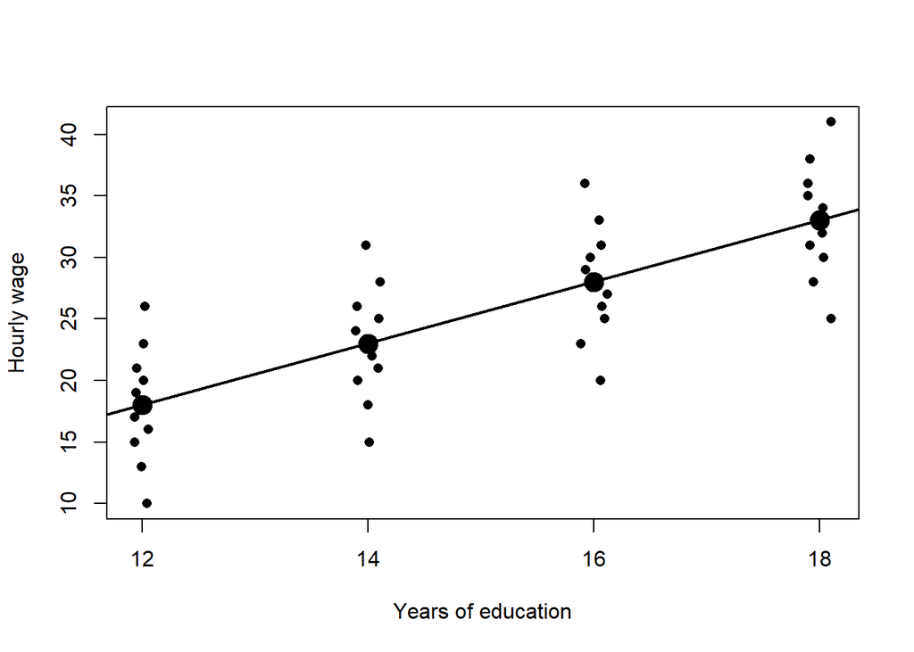

Individual wages and conditional means

```r
jittered_educ <- jitter(workers$educ, amount = 0.12)

plot(
  jittered_educ,
  workers$wage,
  pch = 16,
  xlab = "Years of education",
  ylab = "Hourly wage",
  xaxt = "n"
)
axis(1, at = c(12, 14, 16, 18))

points(
  c(12, 14, 16, 18),
  c(18, 23, 28, 33),
  pch = 19,
  cex = 2
)

abline(a = -12, b = 2.5, lwd = 2)
```

For workers with 16 years of education,

$$WAGE\in[20,36],
\qquad
E(WAGE\mid EDUC=16)=28.$$

**Interpretation:** A prediction of $28 can be sensible even when many individuals earn far from $28. The model describes a conditional mean, not a deterministic outcome.

**Decision:** The wage equation can be useful even when individual predictions contain substantial error.

### Lab Step 4 — How much variation occurs between versus within groups?

**Question:** Is most wage variation associated with differences between education groups, or does most remain among workers with the same education?

**Prediction:** Vote before computing.

```r
pop_var <- function(x) {
  mean((x - mean(x))^2)
}

total_variance <- pop_var(workers$wage)

group_mean_for_each_worker <- ave(
  workers$wage,
  workers$educ,
  FUN = mean
)

between_variance <- mean(
  (group_mean_for_each_worker - mean(workers$wage))^2
)

within_variance <- mean(
  (workers$wage - group_mean_for_each_worker)^2
)

c(
  total = total_variance,
  between = between_variance,
  within = within_variance,
  check = between_variance + within_variance,
  between_share = between_variance / total_variance
)
```

```
        total       between        within         check between_share
   51.8500000    31.2500000    20.6000000    51.8500000     0.6027001
```

**Verified result:**

$$51.85=31.25+20.60.$$

The between-group share is

$$\frac{31.25}{51.85}=0.6027.$$

About **60.3%** of total variation is between education-group means in this deliberately constructed example; about **39.7%** remains within education groups.

**Interpretation:** Both of these can be true at the same time:

- education is strongly informative about wages;
- substantial wage uncertainty remains after conditioning on education.

### Lab Step 5 — Where does regression appear?

**Question:** Given the four conditional means, what intercept and slope should OLS estimate?

**Prediction:** Predict the coefficients before running `lm()`.

```r
model <- lm(wage ~ educ, data = workers)
coef(model)
```

```
(Intercept)        educ
      -12.0         2.5
```

```r
summary(model)$r.squared
```

```
[1] 0.6027001
```

```r
between_variance / total_variance
```

```
[1] 0.6027001
```

**Verified result:**

$$\widehat{WAGE}=-12+2.5EDUC$$

and

$$R^2=0.6027.$$

The same number appears in

$$\frac{\operatorname{Var}[E(WAGE\mid EDUC)]}{\operatorname{Var}(WAGE)}
=0.6027.$$

**ImportantThe reveal**

The probability framework was not a detour. What we have called **between-group variation relative to total variation** is closely connected to what regression calls **explained variation**.

### Deliberate failure / misconception

Consider this interpretation:

> “The model predicts a wage of $28 for someone with 16 years of education. Therefore, a worker with 16 years of education should earn approximately $28 per hour.”

**What is wrong?** The $28 is a fitted conditional mean. Individual wages can differ substantially from it.

Now consider:

> “The coefficient is 2.5, so an additional year of education causes a worker’s wage to rise by $2.50.”

**What is wrong now?** The statistical relationship is conditional association. A causal interpretation requires additional assumptions or research design.

**WarningTwo different mistakes**

$$E(Y\mid X=x)\neq Y_i$$

and

$$\text{association}\neq\text{causal effect}.$$

### Optional 60-second correlation trap

Appendix B emphasizes that independence implies zero correlation, but zero correlation need not imply independence.

```r
set.seed(123)
x <- runif(1000, -1, 1)
y <- x^2

cor(x, y)
```

```
[1] -0.008317744
```

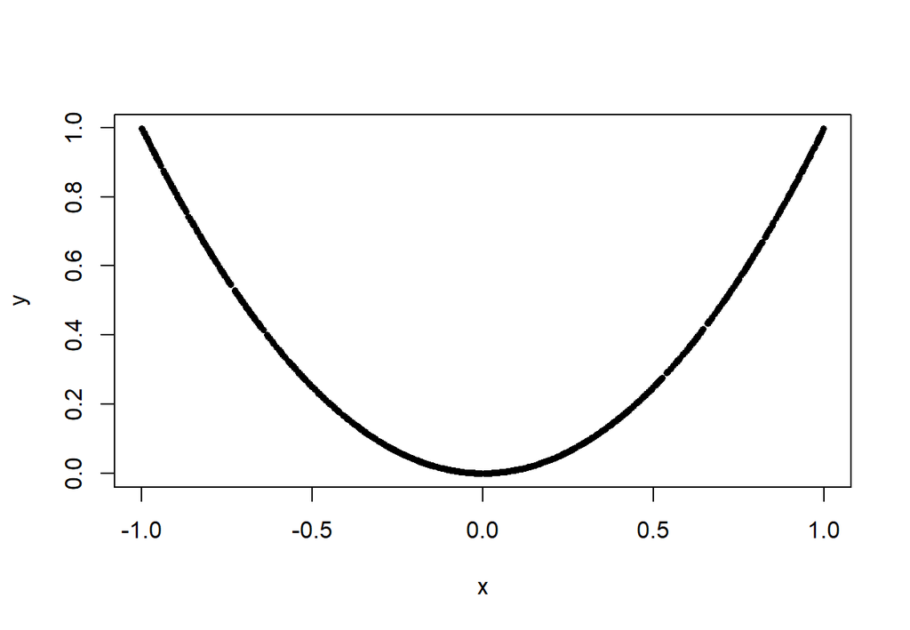

A strong nonlinear relationship with approximately zero linear correlation

```r
plot(x, y, pch = 16, cex = 0.6)
```

**Question:** If correlation is approximately zero, are $X$ and $Y$ unrelated?

**TipClick to view Answer**

No. Here $Y$ is completely determined by $X$, but the relationship is nonlinear and symmetric.

## 4. AI Audit

Give an LLM this exact prompt:

> We observe 40 workers with education levels of 12, 14, 16 and 18 years. Average hourly wages in these groups are $18, $23, $28 and $33. An OLS regression gives $\widehat{WAGE}=-12+2.5EDUC$ with $R^2=0.603$. For a worker with 16 years of education, the model predicts a wage of $28. Explain what the regression tells us about the relationship between education and wages. In particular, explain what the $28 prediction and the coefficient 2.5 mean. Can we conclude that an additional year of education increases a worker’s wage by $2.50?

### Audit framework

Students evaluate the answer on four dimensions:

1. **Conditional mean:** Does the answer recognize that $28 is a fitted conditional mean rather than an exact individual wage?
2. **Remaining uncertainty:** Does it recognize that workers with identical education can have substantially different wages?
3. **$R^2$:** Does it avoid describing $0.603$ as “60.3% accuracy”?
4. **Causality:** Does it distinguish the conditional relationship from a causal return to education?

### Follow-up if the LLM answers correctly

> Your explanation is statistically careful. Now make the strongest possible case that the coefficient 2.5 should **not** be interpreted as the causal return to education. Identify at least three plausible reasons why workers with more education may have higher wages even if education itself is not the only cause. Then explain what additional evidence or research design would make a causal interpretation more credible.

The point is not to catch AI making a mistake. The point is to make students **audit, defend, and stress-test econometric claims**.

## 5. Exit Problem

A housing analyst finds

$$E(RENT)=12{,}000$$

and

$$E(RENT\mid SIZE=80)=15{,}000.$$

Individual 80 m² apartments have rents from NOK 11,000 to NOK 22,000.

**Which statement is best?**

- **A.** An 80 m² apartment should rent for exactly NOK 15,000.
- **B.** Knowing apartment size gives no useful information because actual rents differ from NOK 15,000.
- **C.** Among 80 m² apartments, the expected rent is NOK 15,000, but substantial conditional variation remains.
- **D.** Increasing any apartment to 80 m² will cause its rent to become NOK 15,000.

**TipClick to view Answer**

**Expected answer:** **C**.

- **A** confuses a conditional mean with an individual outcome.
- **B** wrongly rejects useful prediction because observations vary around the prediction.
- **D** turns conditional association into a causal claim.

## Assessment connection

### Part A — Closed-book / individual reasoning

Suppose weekly grocery expenditure $Y$ has the following population information:

| Household size $X$ | Population share | $E(Y\mid X)$ | $\operatorname{Var}(Y\mid X)$ |
| --- | --- | --- | --- |
| 1 | 0.25 | 800 | 40,000 |
| 2 | 0.50 | 1,200 | 90,000 |
| 4 | 0.25 | 1,900 | 160,000 |

**Question 1.** Calculate unconditional expected grocery expenditure.

**Solution:**

$$E(Y)=0.25(800)+0.50(1200)+0.25(1900)=1275.$$

**Question 2.** A four-person household spends NOK 1,450. A student says: “The model predicted NOK 1,900, so the conditional expectation must be wrong.” Diagnose the mistake.

**Solution:** $E(Y\mid X=4)=1900$ is the mean expenditure among four-person households, not the expenditure of every four-person household.

**Question 3.** Household size and grocery expenditure are positively correlated. Can we conclude that adding one person **causes** grocery expenditure to increase by the observed conditional difference?

**Solution:** No. The observed relationship is an association. A causal interpretation requires additional assumptions or research design.

### Part B — Open-book / AI-allowed

Evaluate this claim:

> “Because four-person households spend NOK 1,900 per week compared with NOK 800 for one-person households, adding three people to a household causes weekly grocery expenditure to increase by NOK 1,100.”

**Task:** Is the conclusion justified? Explain which parts are supported and which are not. Identify one piece of additional evidence that would materially strengthen the causal argument.

#### Short grading rubric

- **Insufficient:** Repeats “correlation is not causation” without explaining the inferential problem.
- **Competent:** Correctly identifies NOK 1,100 as a difference in conditional means and explains why it is not automatically causal.
- **Strong:** Clearly distinguishes individual outcomes, conditional expectations, associations, and causal effects, and identifies a credible additional design, control, or identifying assumption.

## What comes next

The next step in econometrics is to formalize the conditional relationship and the part left unexplained. Today’s conceptual expression

$$WAGE_i=E(WAGE\mid EDUC_i)+u_i$$

becomes the foundation for the regression model, fitted values, residuals, explained variation, and eventually statistical inference.

**ImportantTake-home idea**

$$\boxed{E(Y\mid X=x)\neq Y_i}$$

**Econometrics searches for systematic relationships in outcomes that remain uncertain.**

## Instructor notes

**Instructor-only guidance**

**Likely misconceptions**

- “Expected” means “most likely” or “what will happen.”
- A fitted value should be close to every individual observation.
- Conditioning removes all remaining variation.
- A large $R^2$ is the same as high individual prediction accuracy.
- Correlation captures every possible relationship.
- Conditional relationships are automatically causal.

**Where discussion may run long**

The distinction between a good prediction of a mean and a poor prediction of individuals is worth protecting. If discussion is productive, omit the optional $Y=X^2$ correlation trap.

**If time is short**

Keep the contrast $E(Y)$ versus $E(Y\mid X)$ and the idea of total = between + within variation. Skip the optional correlation simulation and shorten the manual variance calculation.

**Questions if the class is quiet**

- If every worker with 16 years of education earned exactly $28, what uncertainty would remain?
- Would we still need an error term?
- What information besides education might change the conditional wage distribution?

**Likely AI-generated answer**

An LLM will probably correctly say that $28 is “an expected or predicted wage, not a guaranteed wage.” Push students to sharpen this: *predicted individual outcome or estimated conditional mean?*

**Single most important idea**

A regression prediction describes a systematic feature of a conditional distribution. It does not turn a random economic outcome into a deterministic one.